# R Notebook

```r
library(car)
```

```r
le = read.csv('Life Expectancy Data.csv')
```

# Data Dictionary

Adult Mortality (Numeric) - # mortalities of adults(15-60) out of 1000 total mortalities.(legal values 0-1000).

infant deaths (Numeric) - # mortalities of infants(0-1) out of 1000.(legal values 0-1000).

Alcohol (Numeric) - avg consumption of pure alcohol. (age>15), (leagal values >=0).

percentage expenditure (Numeric) - how much spend on health as part of GDP.(legal values <= GDP of the same key).

Hepatitis B (Ratio %) - number of 1 year olds with Hepatitis B immunization over all 1 year olds in population in percantage.

Measles (Numeric) - number of reported Measles cases per 1000 population, numbers indicate per population(much more than 1000)

BMI (Numeric) - average Body Mass Index.

under-five deaths (Numeric) - number of people under 5 year’s old that died out of 1000.

Polio (Ratio %) - number of 1 year olds immunized from Polio of out all 1 year olds.

Total expenditure (Ratio %) - General government expenditure on health as a percentage of total government expenditure.

Diphtheria (Ratio %) - Diphtheria tetanus toxoid and pertussis (DTP3) immunization rate of 1 year olds in percantage.

HIV/AIDS (Numeric) - deaths per 1000 live births caused by HIV/AIDS for people ages 0-4.

GDP (Numeric) - Gross Domestic Product per person($).

Population (Numeric) - how many people lived in a country in a specific year.

thinness 1-19 years (Ratio %) - thinness ratio among children and adolescents for Age 10 to 19, name should be fix.

thinness 5-9 yearss (Ratio %) - thinness ratio among children and adolescents for Age 5 to 9.

Income composition of resources (Ratio %) - Human Development Index in terms of income composition of resources (index ranging from 0 to 1)

schooling (Numeric) - average number of schooling years.

# Initial EDA

```r
head(le)
```

|  | Country | Year | Status | Life.expectancy | Adult.Mortality | infant.deaths | Alcohol | percentage.expenditure | Hepatitis.B | Measles | BMI | under.five.deaths | Polio | Total.expenditure | Diphtheria | HIV.AIDS | GDP | Population | thinness..1.19.years | thinness.5.9.years | Income.composition.of.resources | Schooling |
| --- | --- | --- | --- | --- | --- | --- | --- | --- | --- | --- | --- | --- | --- | --- | --- | --- | --- | --- | --- | --- | --- | --- |
| 1 | Afghanistan | 2015 | Developing | 65.0 | 263 | 62 | 0.01 | 71.279624 | 65 | 1154 | 19.1 | 83 | 6 | 8.16 | 65 | 0.1 | 584.25921 | 33736494 | 17.2 | 17.3 | 0.479 | 10.1 |
| 2 | Afghanistan | 2014 | Developing | 59.9 | 271 | 64 | 0.01 | 73.523582 | 62 | 492 | 18.6 | 86 | 58 | 8.18 | 62 | 0.1 | 612.69651 | 327582 | 17.5 | 17.5 | 0.476 | 10.0 |
| 3 | Afghanistan | 2013 | Developing | 59.9 | 268 | 66 | 0.01 | 73.219243 | 64 | 430 | 18.1 | 89 | 62 | 8.13 | 64 | 0.1 | 631.74498 | 31731688 | 17.7 | 17.7 | 0.470 | 9.9 |
| 4 | Afghanistan | 2012 | Developing | 59.5 | 272 | 69 | 0.01 | 78.184215 | 67 | 2787 | 17.6 | 93 | 67 | 8.52 | 67 | 0.1 | 669.95900 | 3696958 | 17.9 | 18.0 | 0.463 | 9.8 |
| 5 | Afghanistan | 2011 | Developing | 59.2 | 275 | 71 | 0.01 | 7.097109 | 68 | 3013 | 17.2 | 97 | 68 | 7.87 | 68 | 0.1 | 63.53723 | 2978599 | 18.2 | 18.2 | 0.454 | 9.5 |
| 6 | Afghanistan | 2010 | Developing | 58.8 | 279 | 74 | 0.01 | 79.679367 | 66 | 1989 | 16.7 | 102 | 66 | 9.20 | 66 | 0.1 | 553.32894 | 2883167 | 18.4 | 18.4 | 0.448 | 9.2 |

```r
summary(le)
```

```
   Country               Year         Status          Life.expectancy Adult.Mortality infant.deaths       Alcohol        percentage.expenditure  Hepatitis.B
 Length:2938        Min.   :2000   Length:2938        Min.   :36.30   Min.   :  1.0   Min.   :   0.0   Min.   : 0.0100   Min.   :    0.000      Min.   : 1.00
 Class :character   1st Qu.:2004   Class :character   1st Qu.:63.10   1st Qu.: 74.0   1st Qu.:   0.0   1st Qu.: 0.8775   1st Qu.:    4.685      1st Qu.:77.00
 Mode  :character   Median :2008   Mode  :character   Median :72.10   Median :144.0   Median :   3.0   Median : 3.7550   Median :   64.913      Median :92.00
                    Mean   :2008                      Mean   :69.22   Mean   :164.8   Mean   :  30.3   Mean   : 4.6029   Mean   :  738.251      Mean   :80.94
                    3rd Qu.:2012                      3rd Qu.:75.70   3rd Qu.:228.0   3rd Qu.:  22.0   3rd Qu.: 7.7025   3rd Qu.:  441.534      3rd Qu.:97.00
                    Max.   :2015                      Max.   :89.00   Max.   :723.0   Max.   :1800.0   Max.   :17.8700   Max.   :19479.912      Max.   :99.00
                                                      NA's   :10      NA's   :10                       NA's   :194                              NA's   :553
    Measles              BMI        under.five.deaths     Polio       Total.expenditure   Diphtheria       HIV.AIDS           GDP              Population
 Min.   :     0.0   Min.   : 1.00   Min.   :   0.00   Min.   : 3.00   Min.   : 0.370    Min.   : 2.00   Min.   : 0.100   Min.   :     1.68   Min.   :        34
 1st Qu.:     0.0   1st Qu.:19.30   1st Qu.:   0.00   1st Qu.:78.00   1st Qu.: 4.260    1st Qu.:78.00   1st Qu.: 0.100   1st Qu.:   463.94   1st Qu.:    195793
 Median :    17.0   Median :43.50   Median :   4.00   Median :93.00   Median : 5.755    Median :93.00   Median : 0.100   Median :  1766.95   Median :   1386542
 Mean   :  2419.6   Mean   :38.32   Mean   :  42.04   Mean   :82.55   Mean   : 5.938    Mean   :82.32   Mean   : 1.742   Mean   :  7483.16   Mean   :  12753375
 3rd Qu.:   360.2   3rd Qu.:56.20   3rd Qu.:  28.00   3rd Qu.:97.00   3rd Qu.: 7.492    3rd Qu.:97.00   3rd Qu.: 0.800   3rd Qu.:  5910.81   3rd Qu.:   7420359
 Max.   :212183.0   Max.   :87.30   Max.   :2500.00   Max.   :99.00   Max.   :17.600    Max.   :99.00   Max.   :50.600   Max.   :119172.74   Max.   :1293859294
                    NA's   :34                        NA's   :19      NA's   :226       NA's   :19                       NA's   :448         NA's   :652
 thinness..1.19.years thinness.5.9.years Income.composition.of.resources   Schooling
 Min.   : 0.10        Min.   : 0.10      Min.   :0.0000                  Min.   : 0.00
 1st Qu.: 1.60        1st Qu.: 1.50      1st Qu.:0.4930                  1st Qu.:10.10
 Median : 3.30        Median : 3.30      Median :0.6770                  Median :12.30
 Mean   : 4.84        Mean   : 4.87      Mean   :0.6276                  Mean   :11.99
 3rd Qu.: 7.20        3rd Qu.: 7.20      3rd Qu.:0.7790                  3rd Qu.:14.30
 Max.   :27.70        Max.   :28.60      Max.   :0.9480                  Max.   :20.70
 NA's   :34           NA's   :34         NA's   :167                     NA's   :163
```

**There are values out of range (infant mortality 1800, max is 1000) multiple NA values**

### Visual EDA - Histogram

Let’s see how our data is distributed

```
Warning: Removed 2563 rows containing non-finite values (stat_bin).
```

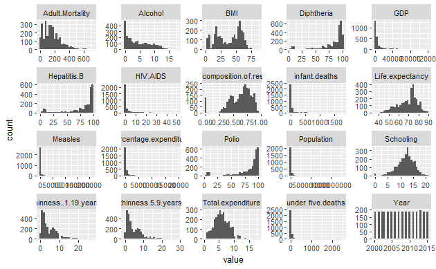

```r
le %>%
  keep(is.numeric) %>%
  gather() %>%
  ggplot(aes(value)) +
  facet_wrap(~ key, scales = 'free') +
  geom_histogram()
```

A lot of values are very Skewed.

There is a categorical variable for devloped or developing nations, let’s look at the difference in life expectancy in the two groups.

```r
le %>%
  group_by(Status) %>%
  summarise(Life_Exp_avg = mean(Life.expectancy, na.rm = TRUE))
```

| Status | Life_Exp_avg |
| --- | --- |
| Developed | 79.19785 |
| Developing | 67.11147 |

More than a 10 percent difference between groups.

Let’s look at numerical correlations.

[figure not shown]

```r
cor(as.data.frame(na.omit(le.num)))[, 2:3]
```

```
                                Life.expectancy Adult.Mortality
Year                                 0.05077103    -0.037091782
Life.expectancy                      1.00000000    -0.702523062
Adult.Mortality                     -0.70252306     1.000000000
infant.deaths                       -0.16907380     0.042450237
Alcohol                              0.40271832    -0.175535086
percentage.expenditure               0.40963082    -0.237609890
Hepatitis.B                          0.19993528    -0.105225443
Measles                             -0.06888122    -0.003966685
BMI                                  0.54204159    -0.351542478
under.five.deaths                   -0.19226530     0.060365026
Polio                                0.32729440    -0.199853000
Total.expenditure                    0.17471764    -0.085226535
Diphtheria                           0.34133123    -0.191428759
HIV.AIDS                            -0.59223629     0.550690745
GDP                                  0.44132181    -0.255034733
Population                          -0.02230498    -0.015011838
thinness..1.19.years                -0.45783819     0.272230044
thinness.5.9.years                  -0.45750829     0.286722882
Income.composition.of.resources      0.72108259    -0.442203288
Schooling                            0.72763003    -0.421170523
```

## Clean Data

**replace NA values with column average**

```r
for(i in 4:ncol(le)){
  le[is.na(le[,i]), i] <-mean(le[,i], na.rm = TRUE)
}
```

check results

```r
summary(le)
```

```
   Country               Year         Status          Life.expectancy Adult.Mortality infant.deaths       Alcohol       percentage.expenditure  Hepatitis.B
 Length:2938        Min.   :2000   Length:2938        Min.   :36.30   Min.   :  1.0   Min.   :   0.0   Min.   : 0.010   Min.   :    0.000      Min.   : 1.00
 Class :character   1st Qu.:2004   Class :character   1st Qu.:63.20   1st Qu.: 74.0   1st Qu.:   0.0   1st Qu.: 1.093   1st Qu.:    4.685      1st Qu.:80.94
 Mode  :character   Median :2008   Mode  :character   Median :72.00   Median :144.0   Median :   3.0   Median : 4.160   Median :   64.913      Median :87.00
                    Mean   :2008                      Mean   :69.22   Mean   :164.8   Mean   :  30.3   Mean   : 4.603   Mean   :  738.251      Mean   :80.94
                    3rd Qu.:2012                      3rd Qu.:75.60   3rd Qu.:227.0   3rd Qu.:  22.0   3rd Qu.: 7.390   3rd Qu.:  441.534      3rd Qu.:96.00
                    Max.   :2015                      Max.   :89.00   Max.   :723.0   Max.   :1800.0   Max.   :17.870   Max.   :19479.912      Max.   :99.00
    Measles              BMI        under.five.deaths     Polio       Total.expenditure   Diphtheria       HIV.AIDS           GDP              Population
 Min.   :     0.0   Min.   : 1.00   Min.   :   0.00   Min.   : 3.00   Min.   : 0.370    Min.   : 2.00   Min.   : 0.100   Min.   :     1.68   Min.   :        34
 1st Qu.:     0.0   1st Qu.:19.40   1st Qu.:   0.00   1st Qu.:78.00   1st Qu.: 4.370    1st Qu.:78.00   1st Qu.: 0.100   1st Qu.:   580.49   1st Qu.:    418917
 Median :    17.0   Median :43.00   Median :   4.00   Median :93.00   Median : 5.938    Median :93.00   Median : 0.100   Median :  3116.56   Median :   3675929
 Mean   :  2419.6   Mean   :38.32   Mean   :  42.04   Mean   :82.55   Mean   : 5.938    Mean   :82.32   Mean   : 1.742   Mean   :  7483.16   Mean   :  12753375
 3rd Qu.:   360.2   3rd Qu.:56.10   3rd Qu.:  28.00   3rd Qu.:97.00   3rd Qu.: 7.330    3rd Qu.:97.00   3rd Qu.: 0.800   3rd Qu.:  7483.16   3rd Qu.:  12753375
 Max.   :212183.0   Max.   :87.30   Max.   :2500.00   Max.   :99.00   Max.   :17.600    Max.   :99.00   Max.   :50.600   Max.   :119172.74   Max.   :1293859294
 thinness..1.19.years thinness.5.9.years Income.composition.of.resources   Schooling
 Min.   : 0.10        Min.   : 0.10      Min.   :0.0000                  Min.   : 0.00
 1st Qu.: 1.60        1st Qu.: 1.60      1st Qu.:0.5042                  1st Qu.:10.30
 Median : 3.40        Median : 3.40      Median :0.6620                  Median :12.10
 Mean   : 4.84        Mean   : 4.87      Mean   :0.6276                  Mean   :11.99
 3rd Qu.: 7.10        3rd Qu.: 7.20      3rd Qu.:0.7720                  3rd Qu.:14.10
 Max.   :27.70        Max.   :28.60      Max.   :0.9480                  Max.   :20.70
```

**use reason to drop columns** + Country name has no bearing on life expectancy, drop it  
+ percentage.expenditure is too highly correlated with GDP, let’s wee which one to keep:

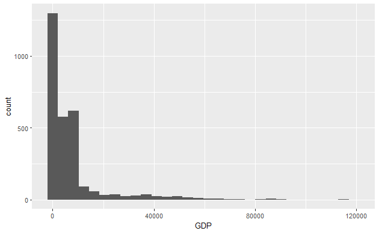

```r
ggplot(le, aes(x = GDP)) + geom_histogram()
```

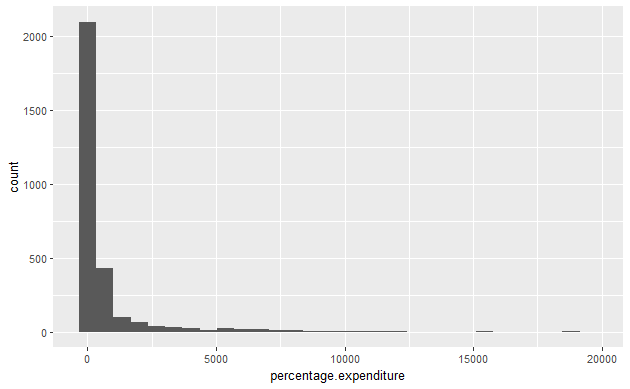

```r
ggplot(le, aes(x=percentage.expenditure)) + geom_histogram()
```

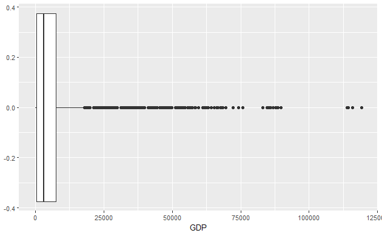

```r
ggplot(le, aes(x = GDP)) + geom_boxplot()
```

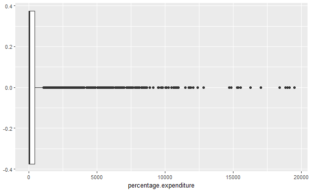

```r
ggplot(le, aes(x = percentage.expenditure)) + geom_boxplot()
```

GDP seems slightly better distributed, drop percentage.expenditure  
+ under.five.deaths and infant.deaths are too highly correlated, drop infant.deaths, because all the data in under.five is included in infant.deaths  
+ thinness.5.9.years data in included in thinness..1.19.years, drop 5.9  
+ Adult Mortality is direct measure of target variable, drop it  
+ Income.composition.of.resources is too highly correlated with income.composition

### Drop Columns

```r
le %>%
  dplyr::select(-c(Adult.Mortality, infant.deaths, percentage.expenditure, thinness.5.9.years, Income.composition.of.resources)) -> le.drop
```

**check for illegal values**

```r
# check for under 5 deaths greater than 1000
le.drop %>%
  filter(under.five.deaths <= 1000) -> le.clean
```

the following columns are supposed to be ratios:

```r
ratios <- c(le.clean$Hepatitis.B, le.clean$Polio, le.clean$Total.expenditure, le.clean$Diptheria, le.clean$thinness..1.19.years, le.clean$Income.composition.of.resources )
le.clean %>%
  dplyr::mutate(Hepatitis.B = round(Hepatitis.B/100, 3)) %>%
  dplyr::mutate(Polio = round(Polio/100, 3)) %>%
  dplyr::mutate(Total.expenditure =round((Total.expenditure/10),3)) %>%
  dplyr::mutate(Diphtheria = round(Diphtheria/100,3)) %>%
  dplyr::mutate(Thinness = round(thinness..1.19.years/100, 3)) %>%
  dplyr::select(-thinness..1.19.years)  -> le.clean
```

Let’s split data into train and test

```r
set.seed(7)
tt <- sample(1:2, size = nrow(le.clean), replace = TRUE, prob=c(0.9, 0.1))
le.train <- le.clean[tt == 1,]
le.test <- le.clean[tt == 2,]
```

Let’s train a model using step wise by AIC

```r
le.train.emptyMod <- lm(Life.expectancy ~ 1, data = le.train[,-c(1,2)])
le.train.fullMod <- lm(Life.expectancy ~ ., data = le.train[,-c(1,2)])
scope = list(lower = formula(le.train.emptyMod), upper = formula(le.train.fullMod))
le.train.FAIC <- step(le.train.emptyMod, scope, direction = 'forward', k=2)
```

```
Start:  AIC=11823.96
Life.expectancy ~ 1

                    Df Sum of Sq    RSS     AIC
+ Schooling          1    121562 115587  9939.5
+ BMI                1     73995 163154 10844.2
+ HIV.AIDS           1     73622 163527 10850.2
+ Thinness           1     59809 177339 11063.1
+ Status             1     55003 182145 11133.3
+ Diphtheria         1     52336 184812 11171.4
+ Polio              1     50012 187136 11204.2
+ GDP                1     43632 193516 11292.2
+ Alcohol            1     36643 200505 11385.4
+ under.five.deaths  1     31451 205697 11452.5
+ Total.expenditure  1     10829 226319 11703.3
+ Hepatitis.B        1      9410 227738 11719.7
+ Measles            1      6287 230861 11755.4
<none>                           237148 11824.0
+ Population         1        51 237098 11825.4

Step:  AIC=9939.46
Life.expectancy ~ Schooling

                    Df Sum of Sq    RSS    AIC
+ HIV.AIDS           1     40377  75210 8813.4
+ BMI                1     12058 103529 9652.3
+ Diphtheria         1     10120 105467 9701.0
+ Polio              1      9164 106423 9724.6
+ Thinness           1      8592 106994 9738.7
+ Status             1      5361 110226 9816.8
+ under.five.deaths  1      5257 110330 9819.3
+ GDP                1      4133 111454 9845.9
+ Hepatitis.B        1      1695 113891 9902.7
+ Measles            1      1375 114212 9910.0
+ Total.expenditure  1       673 114913 9926.1
+ Alcohol            1       373 115214 9933.0
<none>                           115587 9939.5
+ Population         1         0 115587 9941.5

Step:  AIC=8813.39
```

[output cut: 125 more lines]

```
<none>                           55741 8043.0
+ Measles            1    13.819 55727 8044.4
+ Total.expenditure  1    11.091 55730 8044.5
+ Alcohol            1     8.372 55733 8044.6

Step:  AIC=8036.59
Life.expectancy ~ Schooling + HIV.AIDS + Diphtheria + BMI + Status +
    under.five.deaths + GDP + Polio + Thinness + Hepatitis.B +
    Population

                    Df Sum of Sq   RSS    AIC
<none>                           55562 8036.6
+ Measles            1    24.210 55538 8037.4
+ Total.expenditure  1    16.228 55546 8037.8
+ Alcohol            1    10.213 55552 8038.1
```

**let’s look at the model**

```r
summary(le.train.FAIC)
```

```
Call:
lm(formula = Life.expectancy ~ Schooling + HIV.AIDS + Diphtheria +
    BMI + Status + under.five.deaths + GDP + Polio + Thinness +
    Hepatitis.B + Population, data = le.train[, -c(1, 2)])

Residuals:
     Min       1Q   Median       3Q      Max
-19.7854  -2.9502   0.1072   2.8625  18.2300

Coefficients:
                          Estimate       Std. Error t value             Pr(>|t|)
(Intercept)        52.049340095624   0.693399889907  75.064 < 0.0000000000000002 ***
Schooling           1.068890811953   0.038630653127  27.669 < 0.0000000000000002 ***
HIV.AIDS           -0.682167569608   0.018212077060 -37.457 < 0.0000000000000002 ***
Diphtheria          4.730068934117   0.558556561178   8.468 < 0.0000000000000002 ***
BMI                 0.059523262027   0.005818166174  10.231 < 0.0000000000000002 ***
StatusDeveloping   -2.475360433406   0.289118686363  -8.562 < 0.0000000000000002 ***
under.five.deaths  -0.009821967055   0.001189170451  -8.260  0.00000000000000023 ***
GDP                 0.000057662888   0.000007984830   7.222  0.00000000000067099 ***
Polio               3.735768739918   0.532862398062   7.011  0.00000000000300578 ***
Thinness          -10.758482758499   2.808785132600  -3.830             0.000131 ***
Hepatitis.B        -1.737373542510   0.472831263959  -3.674             0.000243 ***
Population          0.000000011794   0.000000004064   2.902             0.003742 **
---
Signif. codes:  0 ‘***’ 0.001 ‘**’ 0.01 ‘*’ 0.05 ‘.’ 0.1 ‘ ’ 1

Residual standard error: 4.611 on 2613 degrees of freedom
Multiple R-squared:  0.7657,    Adjusted R-squared:  0.7647
F-statistic: 776.3 on 11 and 2613 DF,  p-value: < 0.00000000000000022
```

```r
vif(le.train.FAIC)
```

```
        Schooling          HIV.AIDS        Diphtheria               BMI            Status under.five.deaths               GDP             Polio          Thinness
         1.934185          1.100079          2.164653          1.645545          1.506691          1.391846          1.363133          1.924753          1.622841
      Hepatitis.B        Population
         1.375701          1.157281
```

```r
png(file = '2.png')
plot(le.train.FAIC, which =2)
```

**lets do some prediction with our test DF**

```r
le.predictCon <- predict(le.train.FAIC, le.test, interval = 'confidence')
le.predictPred <-predict(le.train.FAIC, le.test, interval = 'prediction')
```

**concat upper and lower confidence and prediction value to test dataframe**

```r
cbind(le.test, 'prediction' = le.predictCon[,1],
      'confidence.lower' = le.predictCon[,2],
      'confidence.upper' = le.predictCon[,3],
      'prediction.lower' = le.predictPred[,2],
      'prediction.upper' = le.predictPred[,3]) -> predictedValues
```

```r
library(ggrepel)
png(file = 'ObsPred.png', height = 450, width = 750)
g <- ggplot(predictedValues, aes(y = Life.expectancy, x = prediction)) + theme(panel.background = element_rect(fill = 'grey75'), plot.title = element_text(size=20, face="bold", vjust=1, lineheight=0.6))
g + geom_point(size = 1.05, color="firebrick") + geom_smooth(method = "lm", se = FALSE, aes(color = 'Regression Line')) +
  geom_abline(intercept = 1.0644, slope = .9923, color = 'darkgreen', se = FALSE, aes(color = 'Confidence Band')) +
  geom_abline(intercept = -.9698, slope = 1.0063, color = 'darkgreen', se = FALSE,  aes(color = 'Confidence  Band')) +
  geom_abline(intercept = 9.0986, slope = .994, color = 'red', se = FALSE, aes(color = 'Prediction Band')) +
  geom_abline(intercept = -9.109, slope = 1.001, color = 'red', se = FALSE, aes(color = 'Prediction Band')) + labs(
    x = 'Predicted Life Expectancy', y = 'Observed Life Expectancy') +
    ggtitle('Observed Vs Predicted Life Expectancy') +
    scale_color_manual(name='Regression Model',
                     breaks=c('Regression Line', 'Confidence Band', 'Prediction Band'),
                     values=c('Prediction Band'='red', 'Regression Line'='blue', 'Confidence Band'='darkgreen'))
```

```r
png(file = 'actual.png')
predictedValues %>%
  dplyr::select(c(Life.expectancy, prediction)) %>%
  ggplot(., aes(y = Life.expectancy)) + geom_boxplot(fill="darkseagreen4") + ggtitle('Distribution of Actual Life Expectancies') + labs(y = 'Life Expectancy') + scale_y_continuous(limits = c(50,90)) +
  theme(panel.background = element_rect(fill = 'grey75'), plot.title = element_text(size=20, face="bold", vjust=1, lineheight=0.6))
```

```r
png(file = 'predict.png')
predictedValues %>%
  dplyr::select(c(Life.expectancy, prediction)) %>%
  ggplot(., aes(y = prediction)) + geom_boxplot(fill="darkseagreen4") + ggtitle('Distribution of Predicted Life Expectancies') + labs(y = 'Life Expectancy') +  scale_y_continuous(position = 'right', limits = c(50,90)) +
  theme(panel.background = element_rect(fill = 'grey75'), plot.title = element_text(size=20, face="bold", vjust=1, lineheight=0.6))
```

```r
t.test(le.test$Life.expectancy, le.predictCon[,1])
```

```
    Welch Two Sample t-test

data:  le.test$Life.expectancy and le.predictCon[, 1]
t = 0.067618, df = 572.71, p-value = 0.9461
alternative hypothesis: true difference in means is not equal to 0
95 percent confidence interval:
 -1.392277  1.491557
sample estimates:
mean of x mean of y
 69.00631  68.95667
```

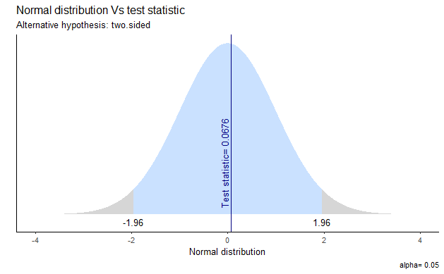

```r
ggttest(t.test(le.test$Life.expectancy, le.predictCon[,1]))
```

Model looks good  
**There are 2 variables that can be tailored to an individual can we input numbers for a person and estimate their life expectancy** + BMI  
+ Schooling

**let’s change the BMI by 10% on the test data and rerun the prediction and see how the values change**

```r
le.test %>%
  mutate(BMI = BMI *1.1) -> le.test.bmi
le.predictBMI <-predict(le.train.FAIC, le.test.bmi, interval = 'prediction')
cbind(le.test, 'Nudge.BMI' = le.test.bmi$BMI, 'prediction.original' = predictedValues$prediction, 'prediction.bmi' = le.predictBMI[,1]) -> nudgeBMI
nudgeBMI
```

|  | Country | Year | Status | Life.expectancy | Alcohol | Hepatitis.B | Measles | BMI | under.five.deaths | Polio | Total.expenditure | Diphtheria | HIV.AIDS | GDP | Population | Schooling | Thinness | Nudge.BMI | prediction.original | prediction.bmi |
| --- | --- | --- | --- | --- | --- | --- | --- | --- | --- | --- | --- | --- | --- | --- | --- | --- | --- | --- | --- | --- |
| 1 | Afghanistan | 2015 | Developing | 65.00000 | 0.010000 | 0.650 | 1154 | 19.10000 | 83 | 0.060 | 0.816 | 0.650 | 0.1 | 584.25921 | 33736494 | 10.10000 | 0.172 | 21.01000 | 61.37374 | 61.48743 |
| 8 | Afghanistan | 2008 | Developing | 58.10000 | 0.030000 | 0.640 | 1599 | 15.70000 | 110 | 0.640 | 0.833 | 0.640 | 0.1 | 373.36112 | 2729431 | 8.70000 | 0.188 | 17.27000 | 60.99655 | 61.09000 |
| 19 | Albania | 2013 | Developing | 77.20000 | 4.760000 | 0.990 | 0 | 56.50000 | 1 | 0.990 | 0.566 | 0.990 | 0.1 | 4414.72314 | 289592 | 14.20000 | 0.013 | 62.15000 | 74.81656 | 75.15286 |
| 23 | Albania | 2009 | Developing | 76.10000 | 5.790000 | 0.980 | 0 | 53.50000 | 1 | 0.980 | 0.579 | 0.980 | 0.1 | 4114.13655 | 2927519 | 12.20000 | 0.015 | 58.85000 | 72.42518 | 72.74363 |
| 24 | Albania | 2008 | Developing | 75.30000 | 5.610000 | 0.990 | 0 | 52.60000 | 1 | 0.990 | 0.587 | 0.990 | 0.1 | 437.53965 | 2947314 | 12.00000 | 0.016 | 57.86000 | 72.00259 | 72.31568 |
| 25 | Albania | 2007 | Developing | 75.90000 | 5.580000 | 0.980 | 22 | 51.70000 | 1 | 0.990 | 0.610 | 0.980 | 0.1 | 363.13685 | 29717 | 11.60000 | 0.016 | 56.87000 | 71.45283 | 71.76057 |
| 29 | Albania | 2003 | Developing | 72.80000 | 4.290000 | 0.970 | 8 | 47.90000 | 1 | 0.970 | 0.627 | 0.970 | 0.1 | 189.68156 | 339616 | 10.70000 | 0.019 | 52.69000 | 70.12138 | 70.40650 |
| 45 | Algeria | 2003 | Developing | 71.70000 | 0.340000 | 0.809 | 15374 | 47.00000 | 23 | 0.870 | 0.360 | 0.870 | 0.1 | 294.33556 | 3243514 | 11.50000 | 0.063 | 51.70000 | 69.70688 | 69.98664 |
| 50 | Angola | 2014 | Developing | 51.70000 | 8.330000 | 0.640 | 11699 | 22.70000 | 101 | 0.680 | 0.331 | 0.640 | 2.0 | 479.31224 | 2692466 | 11.40000 | 0.085 | 24.97000 | 64.35473 | 64.48985 |
| 80 | Antigua and Barbuda | 2000 | Developing | 73.60000 | 7.270000 | 0.809 | 0 | 38.20000 | 0 | 0.960 | 0.413 | 0.950 | 0.1 | 9875.16174 | 12753375 | 0.00000 | 0.037 | 42.02000 | 58.77570 | 59.00308 |

[output cut: 287 more lines]

```r
NA
```

```r
#calculate average difference
nudgeBMI %>%
  summarise(per_change = mean(abs(prediction.bmi - prediction.original)/prediction.original) * 100)
```

| per_change |
| --- |
| 0.324002 |

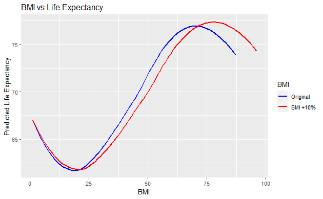

```r
g <- ggplot(nudgeBMI, aes(y = prediction.original, x = BMI))
g + geom_smooth(se = FALSE, aes(color = 'Original')) + geom_smooth(aes(x = Nudge.BMI, y = prediction.bmi, color = 'BMI +10%'), se = FALSE) + labs(
  x = 'BMI', y = 'Predicted Life Expectancy') + ggtitle('BMI vs Life Expectancy') +
  scale_color_manual(name='BMI',
                     breaks=c('Original', 'BMI +10%'),
                     values=c('Original'='blue', 'BMI +10%'='red'))
```

```r
le.test %>%
  mutate(Schooling = Schooling *1.1) -> le.test.schooling
le.predictSchooling <-predict(le.train.FAIC, le.test.schooling, interval = 'prediction')
cbind(le.test, 'Nudge.Schooling' = le.test.schooling$Schooling, 'prediction.original' = predictedValues$prediction, 'prediction.schooling' = le.predictSchooling[,1]) -> nudgeSchooling
nudgeSchooling
```

|  | Country | Year | Status | Life.expectancy | Alcohol | Hepatitis.B | Measles | BMI | under.five.deaths | Polio | Total.expenditure | Diphtheria | HIV.AIDS | GDP | Population | Schooling | Thinness | Nudge.Schooling | prediction.original | prediction.schooling |
| --- | --- | --- | --- | --- | --- | --- | --- | --- | --- | --- | --- | --- | --- | --- | --- | --- | --- | --- | --- | --- |
| 1 | Afghanistan | 2015 | Developing | 65.00000 | 0.010000 | 0.650 | 1154 | 19.10000 | 83 | 0.060 | 0.816 | 0.650 | 0.1 | 584.25921 | 33736494 | 10.10000 | 0.172 | 11.11000 | 61.37374 | 62.45332 |
| 8 | Afghanistan | 2008 | Developing | 58.10000 | 0.030000 | 0.640 | 1599 | 15.70000 | 110 | 0.640 | 0.833 | 0.640 | 0.1 | 373.36112 | 2729431 | 8.70000 | 0.188 | 9.57000 | 60.99655 | 61.92649 |
| 19 | Albania | 2013 | Developing | 77.20000 | 4.760000 | 0.990 | 0 | 56.50000 | 1 | 0.990 | 0.566 | 0.990 | 0.1 | 4414.72314 | 289592 | 14.20000 | 0.013 | 15.62000 | 74.81656 | 76.33438 |
| 23 | Albania | 2009 | Developing | 76.10000 | 5.790000 | 0.980 | 0 | 53.50000 | 1 | 0.980 | 0.579 | 0.980 | 0.1 | 4114.13655 | 2927519 | 12.20000 | 0.015 | 13.42000 | 72.42518 | 73.72923 |
| 24 | Albania | 2008 | Developing | 75.30000 | 5.610000 | 0.990 | 0 | 52.60000 | 1 | 0.990 | 0.587 | 0.990 | 0.1 | 437.53965 | 2947314 | 12.00000 | 0.016 | 13.20000 | 72.00259 | 73.28526 |
| 25 | Albania | 2007 | Developing | 75.90000 | 5.580000 | 0.980 | 22 | 51.70000 | 1 | 0.990 | 0.610 | 0.980 | 0.1 | 363.13685 | 29717 | 11.60000 | 0.016 | 12.76000 | 71.45283 | 72.69275 |
| 29 | Albania | 2003 | Developing | 72.80000 | 4.290000 | 0.970 | 8 | 47.90000 | 1 | 0.970 | 0.627 | 0.970 | 0.1 | 189.68156 | 339616 | 10.70000 | 0.019 | 11.77000 | 70.12138 | 71.26509 |
| 45 | Algeria | 2003 | Developing | 71.70000 | 0.340000 | 0.809 | 15374 | 47.00000 | 23 | 0.870 | 0.360 | 0.870 | 0.1 | 294.33556 | 3243514 | 11.50000 | 0.063 | 12.65000 | 69.70688 | 70.93610 |
| 50 | Angola | 2014 | Developing | 51.70000 | 8.330000 | 0.640 | 11699 | 22.70000 | 101 | 0.680 | 0.331 | 0.640 | 2.0 | 479.31224 | 2692466 | 11.40000 | 0.085 | 12.54000 | 64.35473 | 65.57326 |
| 80 | Antigua and Barbuda | 2000 | Developing | 73.60000 | 7.270000 | 0.809 | 0 | 38.20000 | 0 | 0.960 | 0.413 | 0.950 | 0.1 | 9875.16174 | 12753375 | 0.00000 | 0.037 | 0.00000 | 58.77570 | 58.77570 |

[output cut: 287 more lines]

```r
#calculate average difference
nudgeSchooling %>%
  summarise(per_change = mean(abs(prediction.schooling - prediction.original)/prediction.original) * 100)
```

| per_change |
| --- |
| 1.776379 |

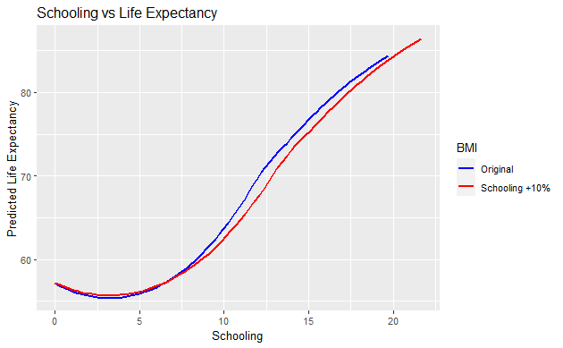

```r
g <- ggplot(nudgeSchooling, aes(y = prediction.original, x = Schooling))
g + geom_smooth(se = FALSE, aes(color = 'Original')) + geom_smooth(aes(x = Nudge.Schooling, y = prediction.schooling, color = 'Schooling +10%'), se = FALSE) + labs(
  x = 'Schooling', y = 'Predicted Life Expectancy') + ggtitle('Schooling vs Life Expectancy') +
  scale_color_manual(name='BMI',
                     breaks=c('Original', 'Schooling +10%'),
                     values=c('Original'='blue', 'Schooling +10%'='red'))
```

```r
expectLife <- function(country,BMI,school){

# need to pull status from df
first(le.clean[le.clean$Country == country,]$Status) -> developing

  le.clean %>%
    dplyr::select(Country, HIV.AIDS, Diphtheria, under.five.deaths, GDP, Polio, Thinness, Hepatitis.B, Population) %>%
    dplyr::filter(Country == country) %>%
    dplyr::select(-Country) %>%
    summarise_all(mean) %>%
    cbind(., 'Status' = developing, 'BMI' = BMI, 'Schooling' = school) -> newwdata
  prediction <- predict(le.train.FAIC, newwdata, interval = 'confidence')
  prediction[,1]

}
expectLife('United States of America', 30, 16)
```

```
[1] 77.22398
```

- **let’s see how our predictions change when a single variable changes**

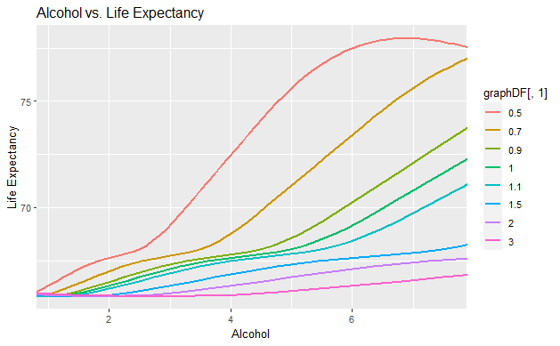

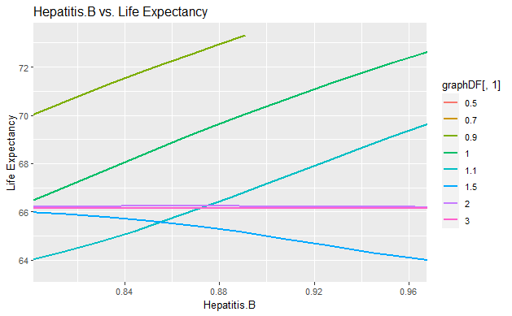

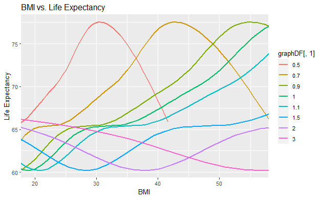

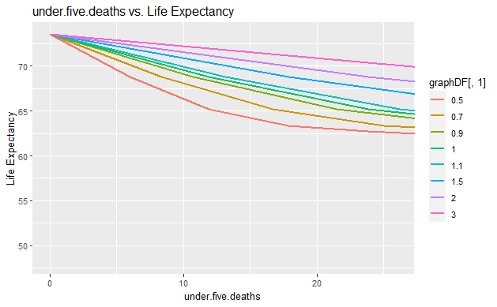

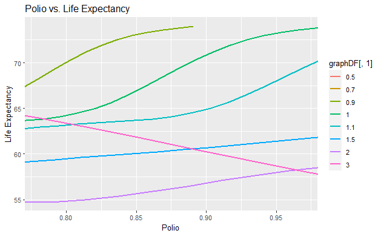

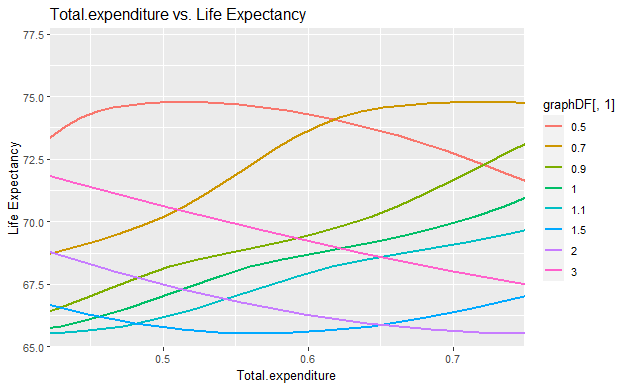

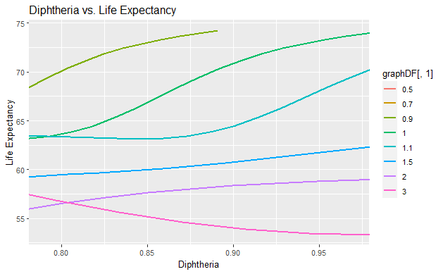

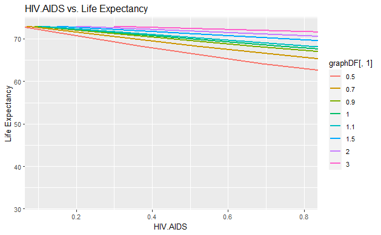

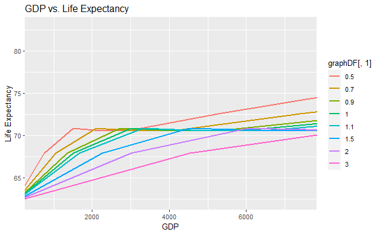

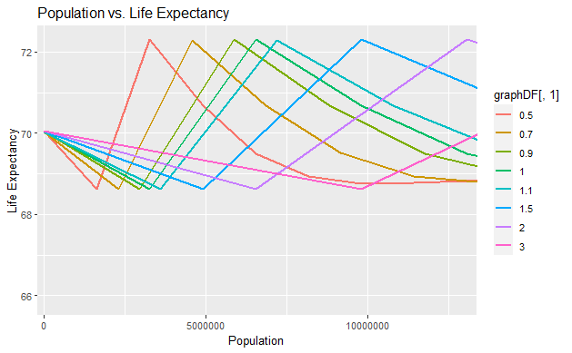

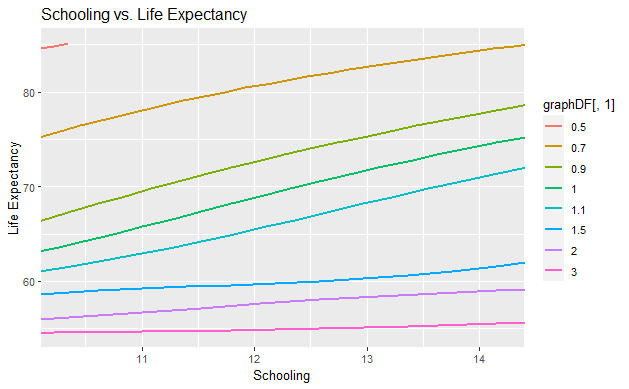

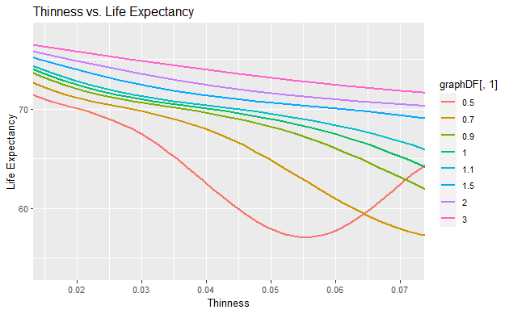

```r
# make a df with only modeled and target variable
le.train %>%
  dplyr::select(-Measles, Total.expenditure, -Country,-Year) -> modeledDF
tempDF <- modeledDF
graphDF <- data.frame()
for (i in 3:ncol(modeledDF)){

  oldColName <- colnames(modeledDF)[i]
  graphname <- paste0(oldColName, '_Graph')
  for (j in c(.5, .7, .9, 1, 1.1, 1.5, 2, 3)){
    newValues <- modeledDF[oldColName] * j
    tempDF[oldColName] <- modeledDF[oldColName] * j
    predictValues <- predict(le.train.FAIC, modeledDF, interval = 'prediction')
    jFrame <- data.frame(as.factor(rep(j, nrow(modeledDF))),
                         tempDF[oldColName],
                         predictValues[,1])
    graphDF <- rbind(graphDF, jFrame)
  }
 colnames(graphDF) <-  c('Nudge', oldColName, 'Predicted')
 g <- ggplot(graphDF, aes(x = graphDF[,2], y = graphDF[,3], colour = graphDF[,1]))
 g <- g + geom_smooth(se = FALSE) + ggtitle(paste0(oldColName, ' vs. Life Expectancy'))
 g <- g + labs(x = oldColName, y = 'Life Expectancy') + coord_cartesian(xlim =  c(quantile(modeledDF[,oldColName], .25), quantile(modeledDF[,oldColName], .75)))

 show(g)
 graphDF <- data.frame()
 tempDF <- modeledDF

}
```

# Creating content for presentation

```r
le %>%
  rename('Adult Mortality' = Adult.Mortality,
         'Life Expectancy' = Life.expectancy,
         'Infant Deaths' = infant.deaths,
         'Alcohol Per Week' = Alcohol,
         'Healthcare Spending of GDP' = percentage.expenditure,
         'Hepatitis B Vax Rate' = Hepatitis.B,
         'Measles Cases' = Measles,
         'Todler Mortality' = under.five.deaths,
         'Polio Vax Rate' = Polio,
         'Health Spending % of Budget' = Total.expenditure,
         'DTP3 Vax Rate' = Diphtheria,
         'Infant HIV/AIDS Deaths' = HIV.AIDS,
         'Adolescent Underweight' = thinness..1.19.years,
         'Toddler Underweight' = thinness.5.9.years,
         'Human Developement Index' = Income.composition.of.resources,
         'Education (Years)' = Schooling) %>%
  dplyr::select(-c(Country, Status)) -> D
round(cor(as.data.frame(na.omit(D))),2) -> C
png(file = 'CompleteCorrelation.png')
corrplot(C, method='circle', type = 'lower', color = 'black')
```

[figure not shown]

[figure not shown]

| Country | Year | HealthIndex |
| --- | --- | --- |
| Afghanistan | 2015 | 0.000016998066963 |
| Afghanistan | 2014 | 0.000099687844050 |
| Afghanistan | 2013 | 0.000101003044725 |
| Afghanistan | 2012 | 0.000740447940535 |
| Afghanistan | 2011 | 0.000891479273073 |
| Afghanistan | 2010 | 0.000458404478110 |
| Afghanistan | 2009 | 0.000554922179432 |
| Afghanistan | 2008 | 0.000362899914922 |
| Afghanistan | 2007 | 0.000283354124150 |
| Afghanistan | 2006 | 0.000394137982622 |

[output cut: 990 more lines]

```r
png(file = 'HealthindexHist.png', height = 400, width = 900)
HealthIndexDF %>%
  ggplot(., aes(x = HealthIndex)) + geom_histogram(aes(y = ..density..), bins = 100, color = "#000000", fill = "#0099F8") +  theme_classic() + xlim(0, .01) + ylim(0,300) +
  ggtitle('Distribution of HealthIndex by Country' )
```

```r
HealthIndexDF %>%
  group_by(Country) %>%
  summarise(meanHI = mean(HealthIndex)) %>%
  arrange(desc(meanHI)) %>%
  top_n(5)%>%
  dplyr::select(Country) -> topCountries
png(file = 'healthindexbyyear.png', height = 400, width = 900)
HealthIndexDF%>%
  filter(Country %in% topCountries$Country) %>%
  ggplot(., aes(x = Year, y = HealthIndex, color = Country)) + geom_line(size = 1) +
  ggtitle('Health Index Over Time by Country') + theme(panel.background = element_rect(fill = 'grey75'), plot.title = element_text(size=20, face="bold", vjust=1, lineheight=0.6))
```

```r
summary(lm(GDP ~ Total.expenditure, data = le.clean))$r.squared
```

```
[1] 0.01438963
```

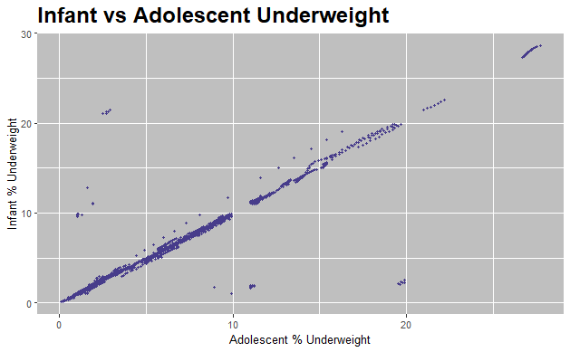

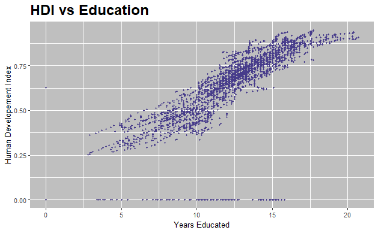